# Chapter 3: Logistic regression

## Reading the data

I start by reading the “alc” data file that I created in the data wrangling excercise. This data file is a combination of two data sets measuring student performance in (1) mathematics and (2) portuguese language in two Portuguese secondary-level schools.

```r
setwd("~/Documents/GitHub/IODS-project/data")
alc <- read.csv(file = "alc.csv")
```

After loading the data, I continue by exploring its structure and dimensions.

```r
str(alc)
```

```
## 'data.frame':    382 obs. of  35 variables:
##  $ school    : Factor w/ 2 levels "GP","MS": 1 1 1 1 1 1 1 1 1 1 ...
##  $ sex       : Factor w/ 2 levels "F","M": 1 1 1 1 1 2 2 1 2 2 ...
##  $ age       : int  18 17 15 15 16 16 16 17 15 15 ...
##  $ address   : Factor w/ 2 levels "R","U": 2 2 2 2 2 2 2 2 2 2 ...
##  $ famsize   : Factor w/ 2 levels "GT3","LE3": 1 1 2 1 1 2 2 1 2 1 ...
##  $ Pstatus   : Factor w/ 2 levels "A","T": 1 2 2 2 2 2 2 1 1 2 ...
##  $ Medu      : int  4 1 1 4 3 4 2 4 3 3 ...
##  $ Fedu      : int  4 1 1 2 3 3 2 4 2 4 ...
##  $ Mjob      : Factor w/ 5 levels "at_home","health",..: 1 1 1 2 3 4 3 3 4 3 ...
##  $ Fjob      : Factor w/ 5 levels "at_home","health",..: 5 3 3 4 3 3 3 5 3 3 ...
##  $ reason    : Factor w/ 4 levels "course","home",..: 1 1 3 2 2 4 2 2 2 2 ...
##  $ nursery   : Factor w/ 2 levels "no","yes": 2 1 2 2 2 2 2 2 2 2 ...
##  $ internet  : Factor w/ 2 levels "no","yes": 1 2 2 2 1 2 2 1 2 2 ...
##  $ guardian  : Factor w/ 3 levels "father","mother",..: 2 1 2 2 1 2 2 2 2 2 ...
```

[output cut: 21 more lines]

```r
dim(alc)
```

```
## [1] 382  35
```

Our data includes 35 variables (columns) and 382 observations (rows). When creating the combined analysis data we have done the following adjustments:

- The variables not used for joining the two data sets have been combined by averaging (including the grade variables)
- ‘alc_use’ is the average of alchohol consumption on workdays (Dalc) and on weekends (Walc)
- The logical variable ‘high_use’ is TRUE if ‘alc_use’ is higher than 2 and FALSE otherwise

## Hypotheses

- Boys are more likely to consume high amounts of alcohol than are girls.
- Those living in an urban address are more likely to consume high amounts of than those living in rural areas due to better access to alcohol.
- Those going out with friends often are more likely to use high amounts of alcohol than those going out less frequently because alcohol is often used with friends.
- Those attending extracurricular activities are less likely to consume high amounts of alcohol because these students are more study-oriented and thus have other things to do.

## Data exploration

Next, I will explore the distributions of the outcome variable and the four chosen explanatory variables. I create a new data frame “alc5” that only includes these five variables. I start by exploring the distributions graphically.

```r
library(tidyr); library(dplyr); library(ggplot2)
alc5 <- select(alc, sex, address, goout, activities, high_use)
```

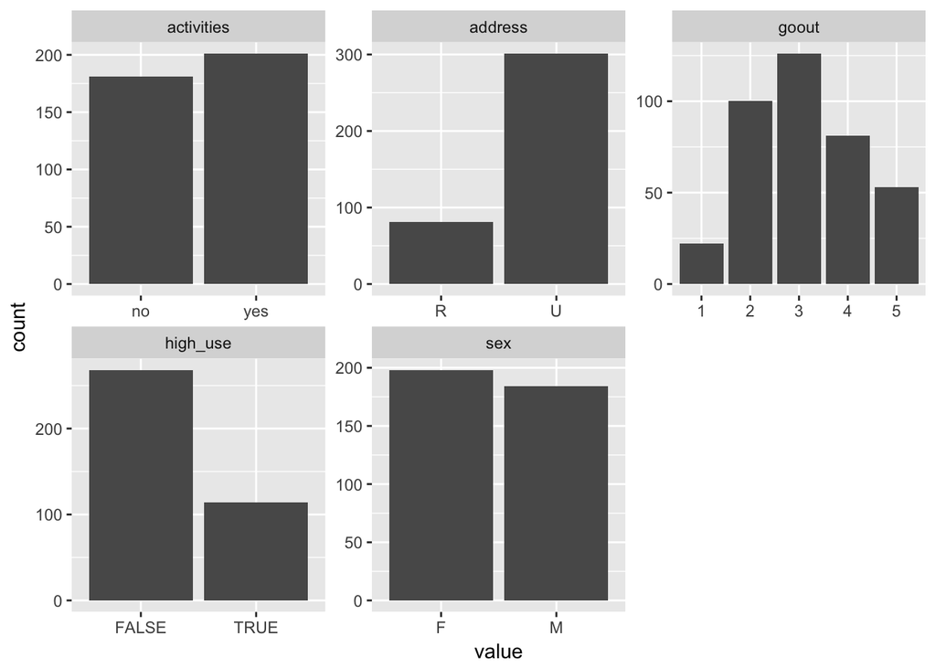

```r
gather(alc5) %>% ggplot(aes(value)) + facet_wrap("key", scales = "free") + geom_bar()
```

Around half of the students attend extracurricular activities. Living in an urban area is more common than living in a rural area, and the extremes of going out with friends are less common than the middle of the scale. Girls are only slightly overrepresented in the sample. Around one third of the sample engages in high alcohol use.

I continue by looking at the relative frequencies of low/high alcohol use by the four explanatory variables.

```r
table(alc5$activities, alc5$high_use) %>% prop.table(1) %>% round(2)
```

```
##
##       FALSE TRUE
##   no   0.67 0.33
##   yes  0.73 0.27
```

```r
table(alc5$address, alc5$high_use) %>% prop.table(1) %>% round(2)
```

```
##
##     FALSE TRUE
##   R  0.62 0.38
##   U  0.72 0.28
```

```r
table(alc5$goout, alc5$high_use) %>% prop.table(1) %>% round(2)
```

```
##
##     FALSE TRUE
##   1  0.86 0.14
##   2  0.84 0.16
##   3  0.82 0.18
##   4  0.51 0.49
##   5  0.40 0.60
```

```r
table(alc5$sex, alc5$high_use) %>% prop.table(1) %>% round(2)
```

```
##
##     FALSE TRUE
##   F  0.79 0.21
##   M  0.61 0.39
```

Those attending extracurricular activities are slightly less common to have high alcohol consumption, as hypothesized. Opposite to the hypothesis, consuming high amounts of alcohol is less common for those living in urban areas. In line with my hypothesis, high alcohol use is more common among students going out with friends often and male students.

## Logistic regression

I move on to estimating a logistic regression model with high alcohol use as the outcome variable and activities, address, going out with friends and sex as explanatory variables.

```r
m <- glm(high_use ~ activities + address + goout + sex, data = alc5, family = "binomial")
summary(m)
```

```
##
## Call:
## glm(formula = high_use ~ activities + address + goout + sex,
##     family = "binomial", data = alc5)
##
## Deviance Residuals:
##     Min       1Q   Median       3Q      Max
## -1.7579  -0.7750  -0.5065   0.7677   2.4999
##
## Coefficients:
##               Estimate Std. Error z value Pr(>|z|)
## (Intercept)    -3.1340     0.4927  -6.361 2.00e-10 ***
## activitiesyes  -0.5145     0.2532  -2.032  0.04215 *
## addressU       -0.7487     0.2995  -2.500  0.01242 *
## goout           0.8028     0.1212   6.622 3.55e-11 ***
## sexM            0.9398     0.2536   3.706  0.00021 ***
## ---
## Signif. codes:  0 '***' 0.001 '**' 0.01 '*' 0.05 '.' 0.1 ' ' 1
##
## (Dispersion parameter for binomial family taken to be 1)
##
##     Null deviance: 465.68  on 381  degrees of freedom
## Residual deviance: 392.97  on 377  degrees of freedom
## AIC: 402.97
##
## Number of Fisher Scoring iterations: 4
```

```r
OR <- coef(m) %>% exp %>% round(2)
CI <- confint(m) %>% exp %>% round(2)
cbind(OR, CI)
```

```
##                 OR 2.5 % 97.5 %
## (Intercept)   0.04  0.02   0.11
## activitiesyes 0.60  0.36   0.98
## addressU      0.47  0.26   0.85
## goout         2.23  1.77   2.85
## sexM          2.56  1.57   4.24
```

Overall, our hypotheses related extracurricular activities, going out with friends and sex were supported by the logistic regression analysis. On the other hand, I hypothesized that urban residence would be associated with higher propability of high alcohol use, while in the analysis urban residence was in fact associated with much lower odds high use.

## Predictive power

Next, I will explore the predictive power of my logistic model where all explanatory variables were clearly associated with the odds of high alcohol use. I begin by creating a 2x2 table, which shows the numbers of correct and false predictions.

```r
# predict() the probability of high_use
probabilities <- predict(m, type = "response")

# add the predicted probabilities to 'alc'
alc5 <- mutate(alc5, probability = probabilities)

# use the probabilities to make a prediction of high_use
alc5 <- mutate(alc5, prediction = probability > 0.5)

# tabulate the target variable versus the predictions
table(high_use = alc5$high_use, prediction = alc5$prediction)
```

```
##         prediction
## high_use FALSE TRUE
##    FALSE   245   23
##    TRUE     71   43
```

We can see that for 245 cases the model correctly predicted that they do not use high amounts of alcohol and for 43 cases that they do have high alcohol use. On the other hand, 71 cases were incorrectly classified as not-high-users while in reality they were high-users.

I continue by (1) creating a graph of the actual cases and predictions of high use, (2) a propability table of the predictions and finally (3) a function calculating the number of incorrect predictions.

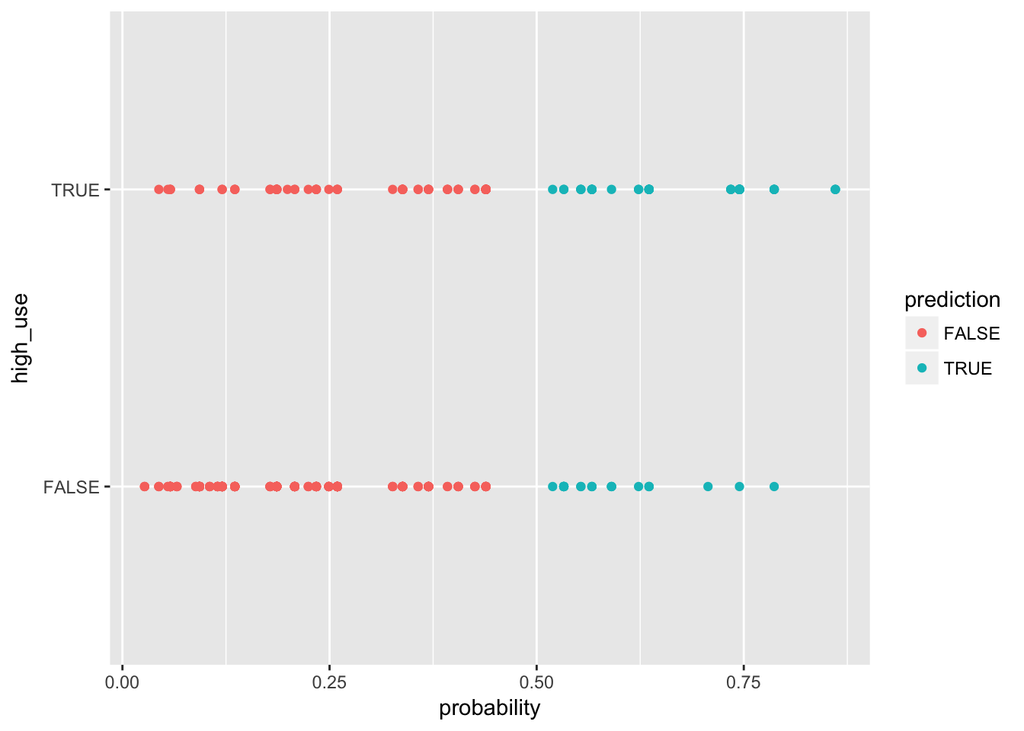

```r
# initialize a plot of 'high_use' versus 'probability' in 'alc'
g <- ggplot(alc5, aes(x = probability, y = high_use, col = prediction))

# define the geom as points and draw the plot
g + geom_point()
```

```r
# tabulate the target variable versus the predictions
table(high_use = alc5$high_use, prediction = alc5$prediction) %>% prop.table() %>% addmargins() %>% round(2)
```

```
##         prediction
## high_use FALSE TRUE  Sum
##    FALSE  0.64 0.06 0.70
##    TRUE   0.19 0.11 0.30
##    Sum    0.83 0.17 1.00
```

```r
# define a loss function (mean prediction error)
loss_func <- function(class, prob) {
  n_wrong <- abs(class - prob) > 0.5
  mean(n_wrong)
}

# call loss_func to compute the average number of wrong predictions in the (training) data
loss_func(class = alc5$high_use, prob = alc5$probability)
```

```
## [1] 0.2460733
```

Looking at the graph, we can see that there were quite many cases who were predicted to have low propability of high alcohol use but were still high users. Around 19% of predictions were incorrect in that way, while only 6% of cases were incorrectly predicted to have high use when in reality they did not have. Overall, around one fourth of cases were incorrectly classified on account of their alcohol use. This result is definitely better than tossing a coin and quite good actually given that we only had four explanatory varibles in the model. At the same time, one fourth is still pretty large a proportion of false predictions and could probably be improved by including more variables.

## Cross-validation

Using the above-defined loss function I can perform a ten-fold cross-validation on my model. In this cross-validations the analysis data is first divided into ten equal sized parts. Each part in turn acts a “testing data” while the other nine parts form a “training data”. Training data is used for fitting the model while the testing data is used for testing it. Based, on the ten tests we can calculate the average number of wron predictions.

```r
# K-fold cross-validation
library(boot)
cv <- cv.glm(data = alc5, cost = loss_func, glmfit = m, K = 10)

# average number of wrong predictions in the cross validation
cv$delta[1]
```

```
## [1] 0.2434555
```

In the ten-fold cross-validation the predition error was around one fourth i.e. about the same as the prediction error of our original full-sample model. My prediction error was also about the same as in the Datacamp excercise, although I mostly used a different set of explanatory variables.